# How to Buy a House as a Data Scientist

Avriana Allen

3/15/2020

# How to Buy a House as a Data Scientist

#### Predicting heating costs with the 2015 Residential Energy Consumption Survey

##### Avriana Allen | March 15, 2020

### The Data

The 2015 Residential Energy Consumption Survey, (the RECS), was created from a housing survey randomly assigned to over 5 thousand households combined with energy consumption and billing data from their energy suppliers. With broad and specific questions, the survey tallies everything from the number of occupants to the number of swamp coolers for any given household.

Looking at all the data, I wondered, would it be possible to predict heating costs or energy use for a household accurately? If so, what would the predictors be?

After removing the imputation flags, and hand selecting 132 possible predictors, I split the data into four pieces. 70 percent was set aside for model building while the remaining 30 percent was split three ways: exploration, selection and performance.

### Selecting a predictor

The first question I asked was what to predict? There were two potential candidates, the total amount of money spent on heating, or the total amount of energy spend on heating. To decide between the two options, I selected all the non-categorical variables, 39 not counting my two potential candidates and considered the correlations.

Correlation to Money Spent on Heating

| id | totaldolsph |
| --- | --- |
| totaldol | 0.671487 |
| totalbtusph | 0.761742 |
| totaldolsph | 1.000000 |

Correlation to Energy Expended on Heating

| id | totalbtusph |
| --- | --- |
| hdd30yr | 0.5139485 |
| hdd65 | 0.5302723 |
| hdd50 | 0.5249102 |
| cufeetng | 0.7169301 |
| cufeetngsph | 0.7914406 |
| btung | 0.7183729 |
| btungsph | 0.7933099 |
| dollarng | 0.6156144 |
| dolngsph | 0.7292990 |
| totaldol | 0.5080322 |
| totalbtusph | 1.0000000 |
| totaldolsph | 0.7617420 |

Any correlation under 0.5 was dropped, leaving me leaning toward predicting the amount of energy spent on heating. It had more variables so I thought it would be more interesting to work with.

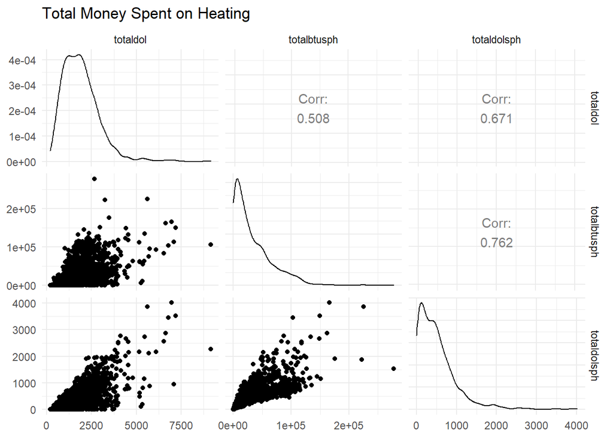

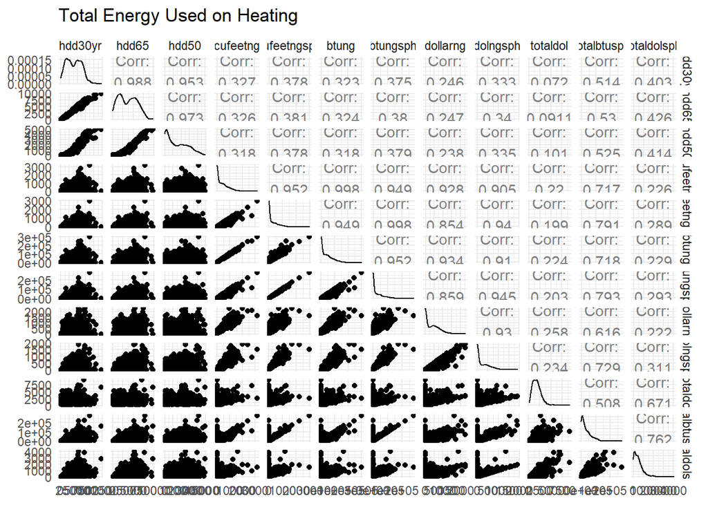

The pairwise plots confirmed my thoughts. I would predict the amount of energy spent on heating.

### Reducing the predictors

Moving into model building, I knew I had set of continuous predictors. However, I still had close to 90 categorical variables. I decided to use a lasso to reduce this number.

Using a formula containing all the categorical variables, I used cross-fold validation to keep only the variables that the lasso deemed important, reducing the number of variables I intended to use from 90 to 54.

Sample of the Remaining Variables

| name | lasso_min | lasso_1se | variable_name | variable_description | type | response_names | response_values |
| --- | --- | --- | --- | --- | --- | --- | --- |
| (Intercept) | 26359.796360 | 25645.081273 | NA | NA | NA | NA | NA |
| division2 | 2164.800263 | NA | division | Census Division | factor | Middle Atlantic | 2 |
| division3 | 4262.756727 | 1133.428022 | division | Census Division | factor | East North Central | 3 |
| division5 | -3856.750946 | -961.006844 | division | Census Division | factor | South Atlantic | 5 |
| division9 | 925.585702 | NA | division | Census Division | factor | Mountain South | 9 |
| division10 | -4539.333737 | -1960.453116 | division | Census Division | factor | Pacific | 10 |
| uatyp10R | 175.106958 | NA | uatyp10 | Census 2010 Urban Type | factor | Rural | R |
| uatyp10U | -1187.610699 | NA | uatyp10 | Census 2010 Urban Type | factor | Urban Area | U |
| typehuq2 | 5440.012160 | 5678.123695 | typehuq | Type of housing unit | factor | Single-family detached house | 2 |
| typehuq5 | -3320.018126 | -4717.369019 | typehuq | Type of housing unit | factor | Apartment in a building with 5 or more units | 5 |
| stories20 | 4367.348514 | 4379.559590 | stories | Number of stories in a single-family home | factor | Two stories | 20 |
| stories31 | 10922.534462 | 2964.288494 | stories | Number of stories in a single-family home | factor | Three stories | 31 |
| stories40 | 6097.891495 | NA | stories | Number of stories in a single-family home | factor | Split-level | 40 |
| yearmaderange1 | 1743.131800 | 79.881218 | yearmaderange | Range when housing unit was built | factor | Before 1950 | 1 |
| yearmaderange2 | 47.290056 | NA | yearmaderange | Range when housing unit was built | factor | 1950 to 1959 | 2 |
| yearmaderange4 | 470.038777 | NA | yearmaderange | Range when housing unit was built | factor | 1970 to 1979 | 4 |
| yearmaderange6 | -823.533105 | NA | yearmaderange | Range when housing unit was built | factor | 1990 to 1999 | 6 |
| yearmaderange8 | -1618.893749 | NA | yearmaderange | Range when housing unit was built | factor | 2010 to 2015 | 8 |
| occupyyrange4 | 1663.536408 | NA | occupyyrange | Range when household moved in | factor | 1970 to 1979 | 4 |
| occupyyrange8 | -2402.027625 | -1973.821248 | occupyyrange | Range when household moved in | factor | 2010 to 2015 | 8 |
| bedrooms2 | -1320.363852 | -422.146959 | NA | NA | NA | NA | NA |
| bedrooms6 | 3556.027105 | NA | NA | NA | NA | NA | NA |
| ncombath0 | 16118.964592 | NA | NA | NA | NA | NA | NA |
| ncombath1 | -982.586009 | NA | NA | NA | NA | NA | NA |
| ncombath4 | 10691.808077 | 5525.730431 | NA | NA | NA | NA | NA |
| ncombath5 | 18231.888912 | NA | NA | NA | NA | NA | NA |
| walltype4 | -1676.902592 | -1105.505111 | walltype | Major outside wall material | factor | Stucco | 4 |
| walltype6 | 6181.113854 | NA | walltype | Major outside wall material | factor | Stone | 6 |
| walltype9 | 2098.004756 | NA | walltype | Major outside wall material | factor | Other | 9 |
| rooftype-2 | -1207.985883 | NA | rooftype | Major roofing material | factor | Not applicable | -2 |

[output cut: 88 more lines]

### Formulas and Functions

My initial look at the correlations between variables and the total amount of energy spent on heating suggested that there might be a strong linear correlation. I decided to begin by trying a linear model with three different formulas.

The first contained only the variables that were categorical, the second all the variables that were continuous, and the final model contained all the variables.

### Fitting a Linear Model

Given the number of variables, I decided to use 5 folds instead of 10 for fitting my linear models. After creating a data set with these folds, the formulas and the respective fits, I averaged the R and R-squared tests to see how much of the variance was explained.

Linear Model Comparisons

| form_name | r_squared | adj_r_squared |
| --- | --- | --- |
| all | 0.9774030 | 0.9758090 |
| cont | 0.9532564 | 0.9530944 |
| fact | 0.6702420 | 0.6482799 |

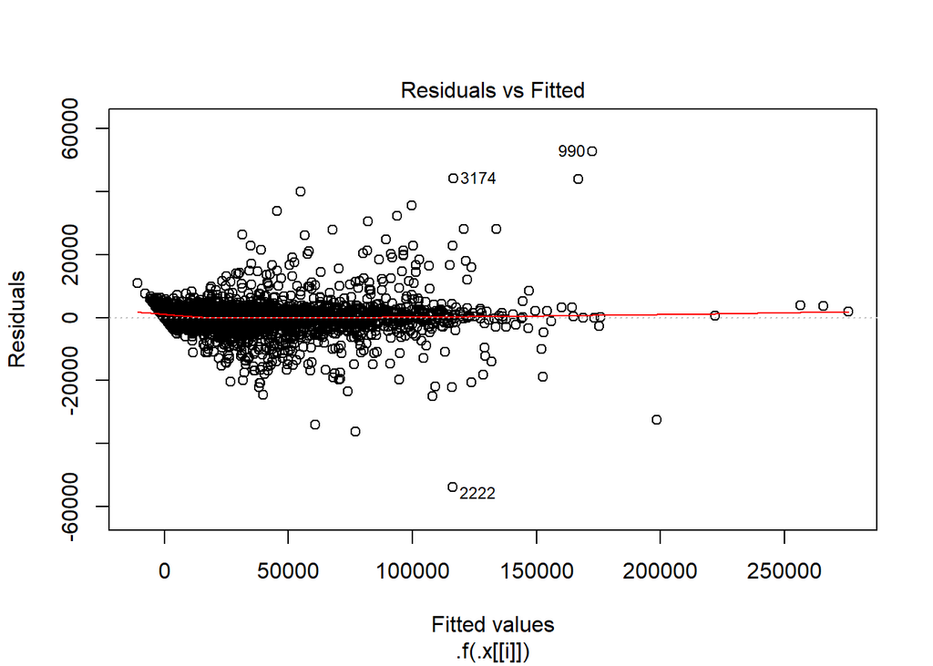

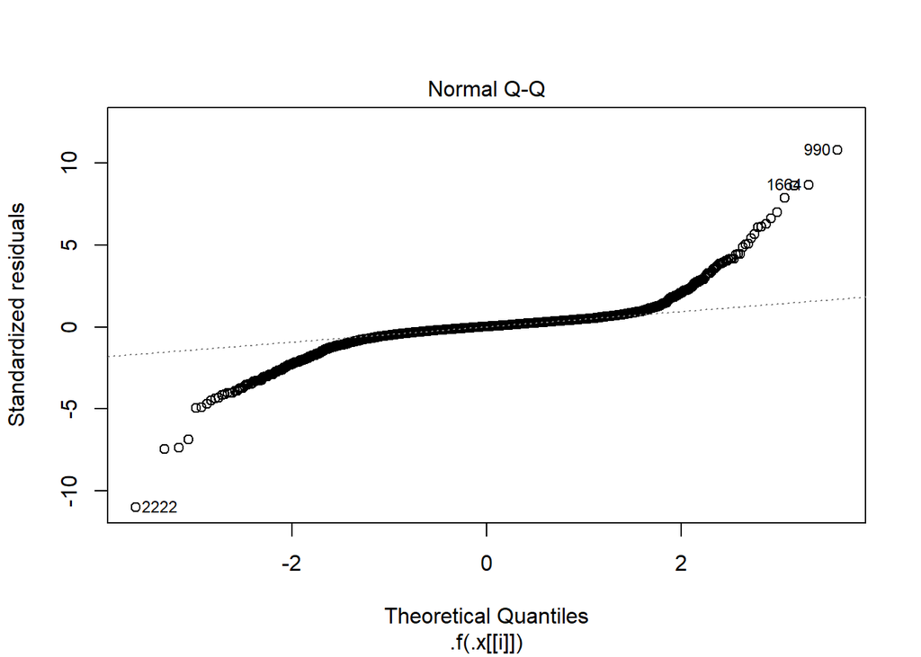

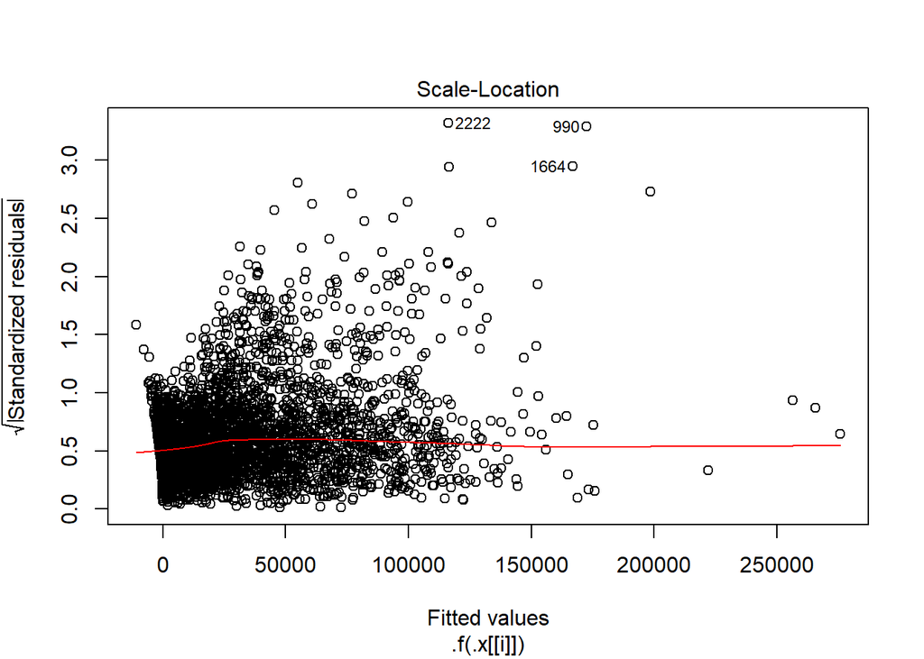

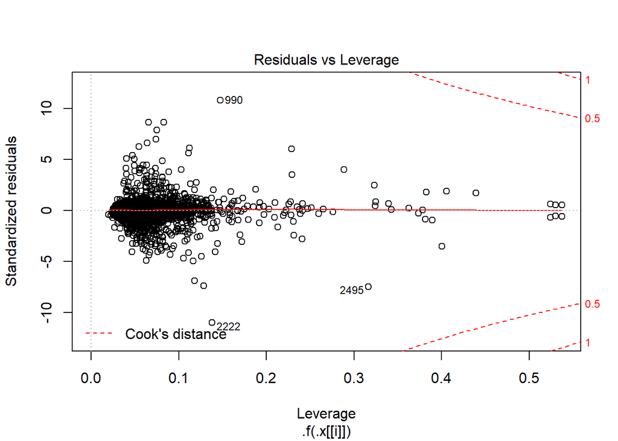

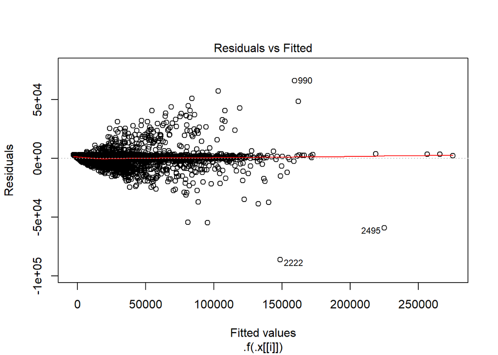

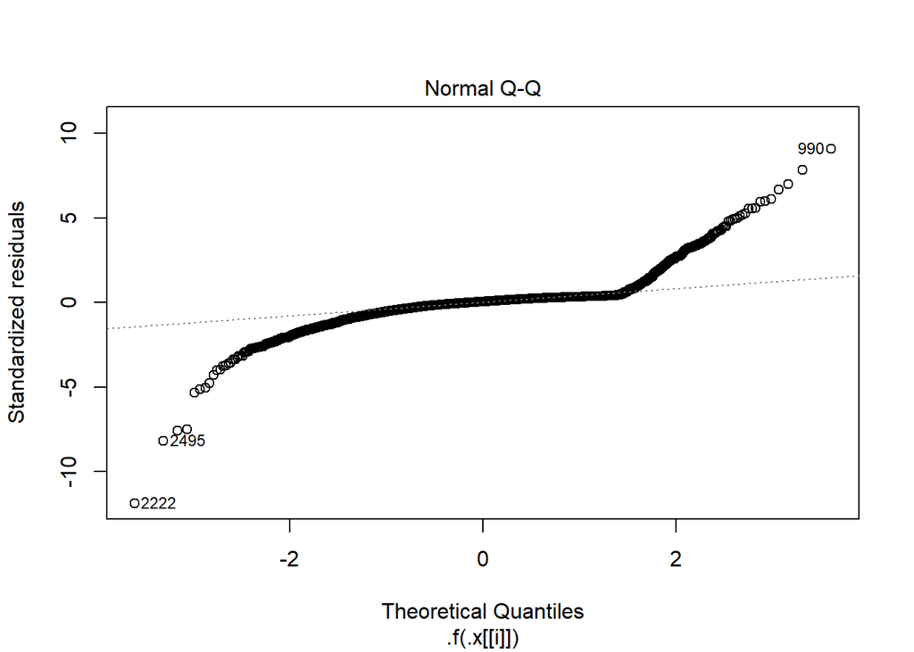

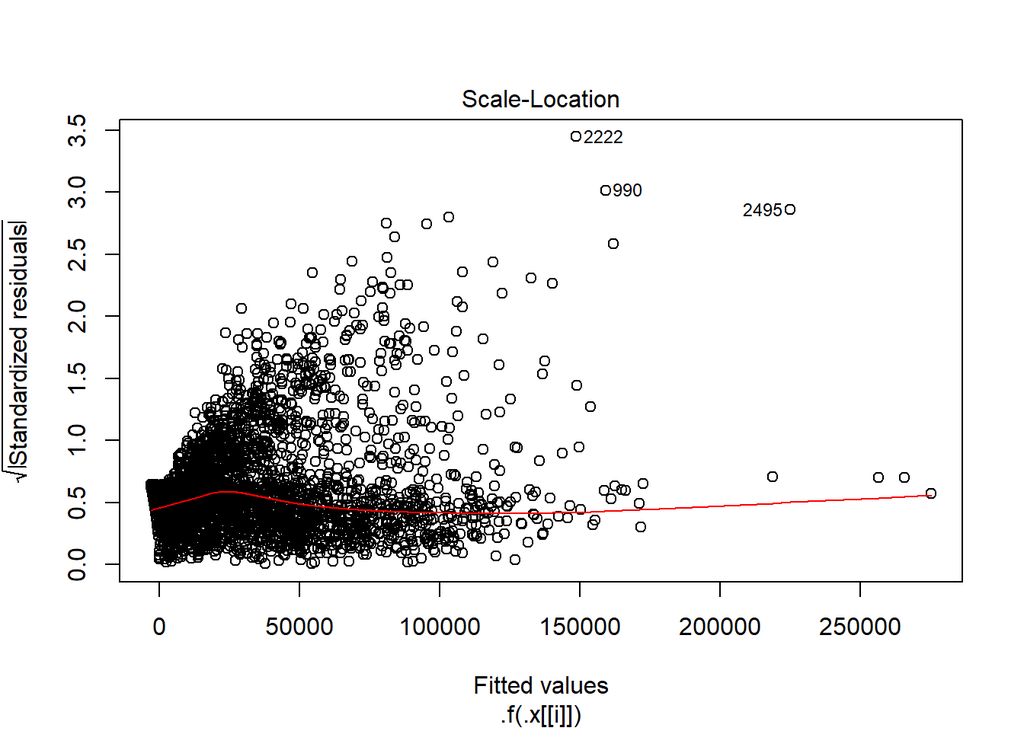

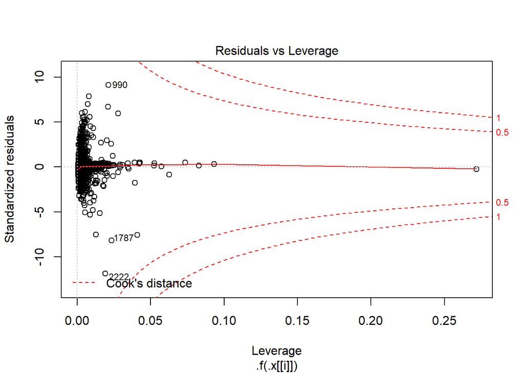

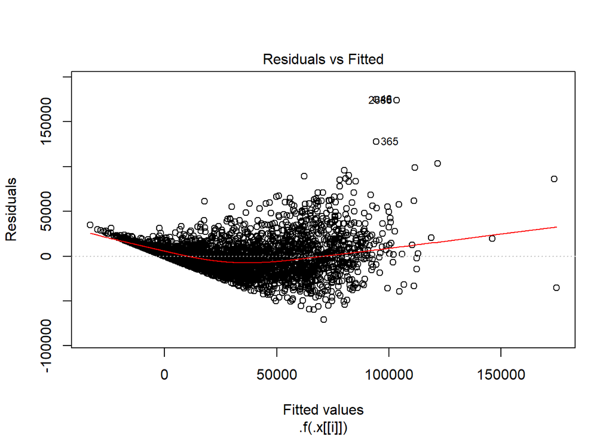

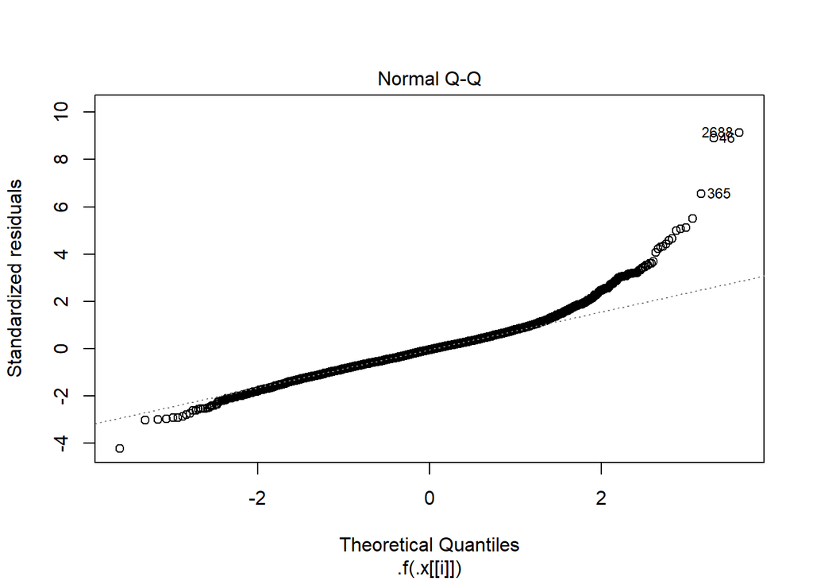

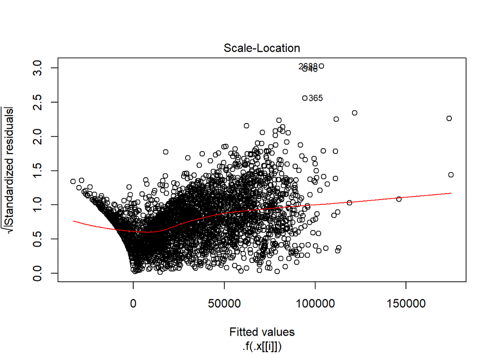

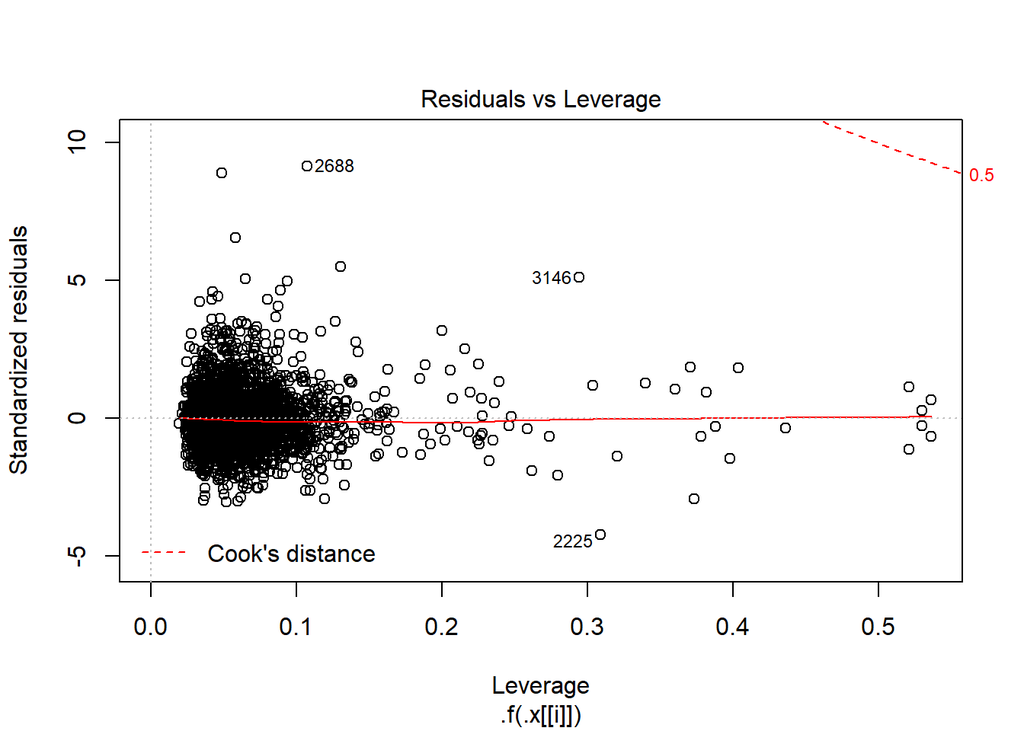

### Fitting a Lasso

The best linear model contains a high number of variables. I wanted to know if all of the variables were needed, so I ran a lasso using the formula with all of the preselected variables. To do this, I split the data into two pieces, a training set of about 75 percent of the data and a test set of the remaining 25 percent.

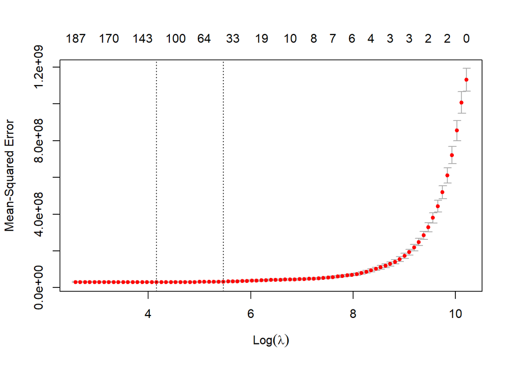

On the training data, I used a 10-fold cross-validated lasso to choose my lambada. I created a new data set that contained the lasso fits and used it to calculate the MSE, MSE squared and amount of variance explained.

Lasso Model Comparisons

| method | test_mse | explained |
| --- | --- | --- |
| lasso_min | 32599395 | 0.9714315 |
| lasso_1se | 132389834 | 0.8839802 |

The lasso does better than two of the linear models but doesn’t quite beat out our top linear model.

### Subsets and Random Forests

Although it was simple to apply, and fit the data quite well, I lacked the understanding to know exactly what it was doing, though I understood the concept behind it.

### Models to Pass

Based upon the different models I have tried, I decided to pass three models to compete in selection. They are the top two linear models and the lasso.

### Model Selection

To compare the three models, I created two data sets; one for lasso and the other for the two linear models. I compared the lasso’s amount of explained variance and the R and R-Squared tests to see which model did best on this untouched data.

Linear Models

| form_name | r_squared | adj_r_squared |
| --- | --- | --- |
| all | 0.9809229 | 0.9764083 |
| cont | 0.9555250 | 0.9550589 |

Lasso Models

| method | test_mse | explained |
| --- | --- | --- |
| lasso_min | 32713638 | 0.9712505 |
| lasso_1se | 112973248 | 0.9007164 |

Each model performs quite well, so I decided to graph the predicted values from each model against the true values and see I could gain any insight.

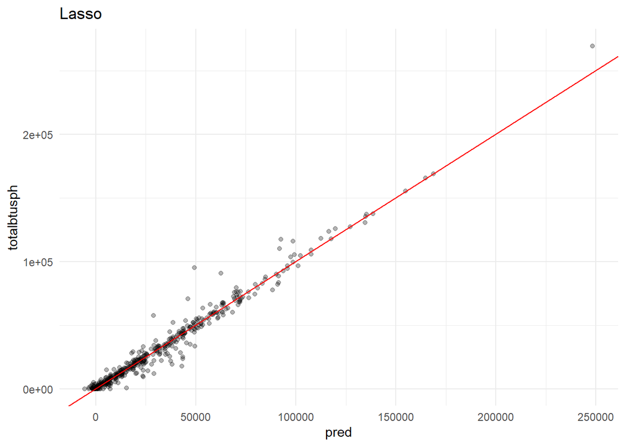

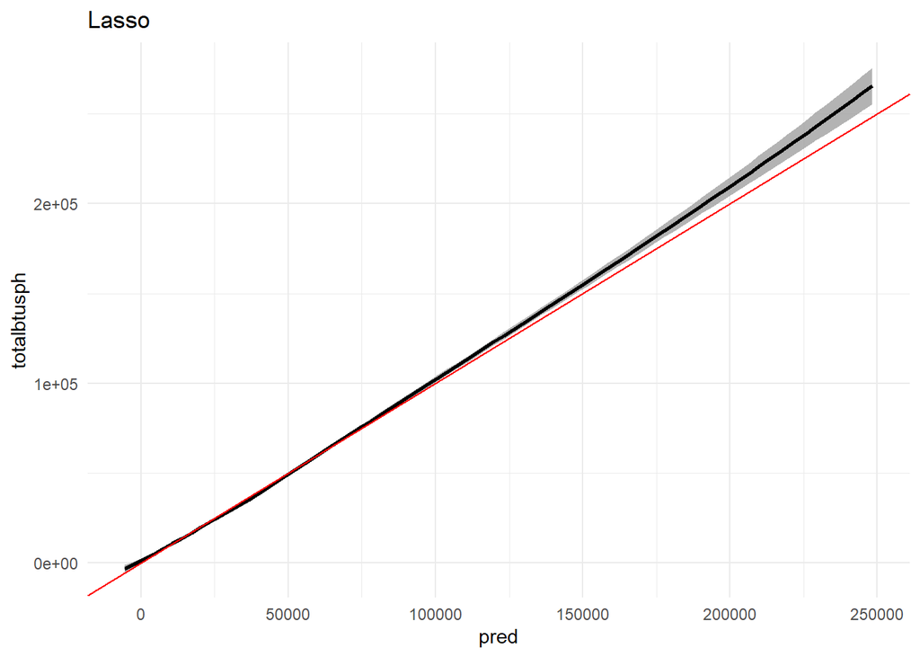

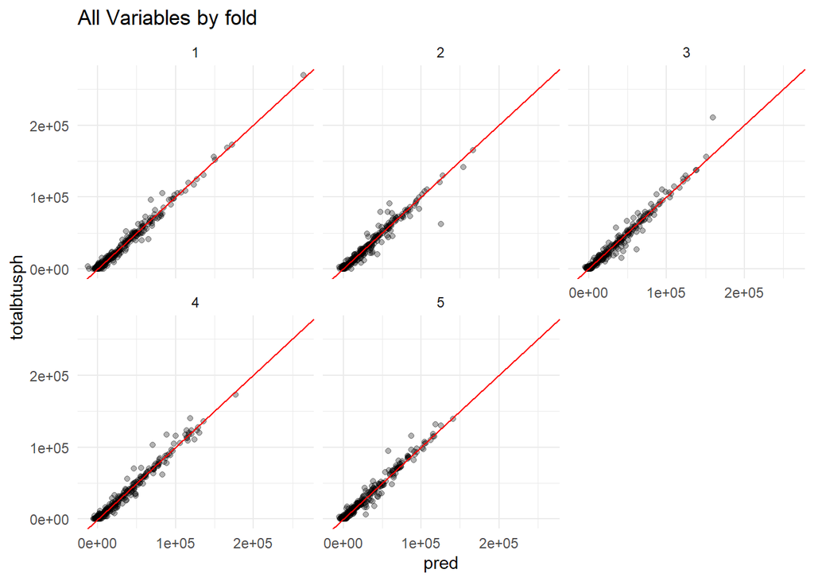

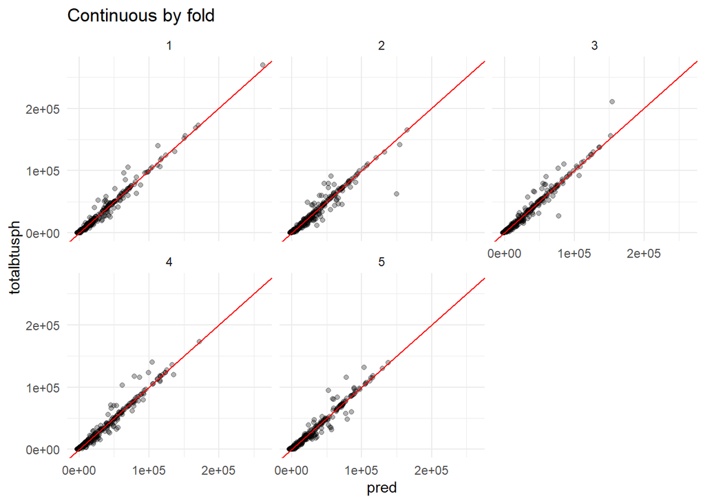

I decided that the lasso would be my final model because it performed at the same level as the linear model, but, at least in theory, reduced the number of variables in use.

### Final Model

Unpacking the final data, I created a new data set that contained the lasso and selected the lambada, before fitting it to the performance set and calculating the amount of explained variance.

Final Model Fit

| method | test_mse | explained |
| --- | --- | --- |
| lasso_min | 27025709 | 0.9788629 |
| lasso_1se | 118441058 | 0.9073660 |

Looking at the predictions verses the actual data, we can see that the model does a great job of predicting the data.

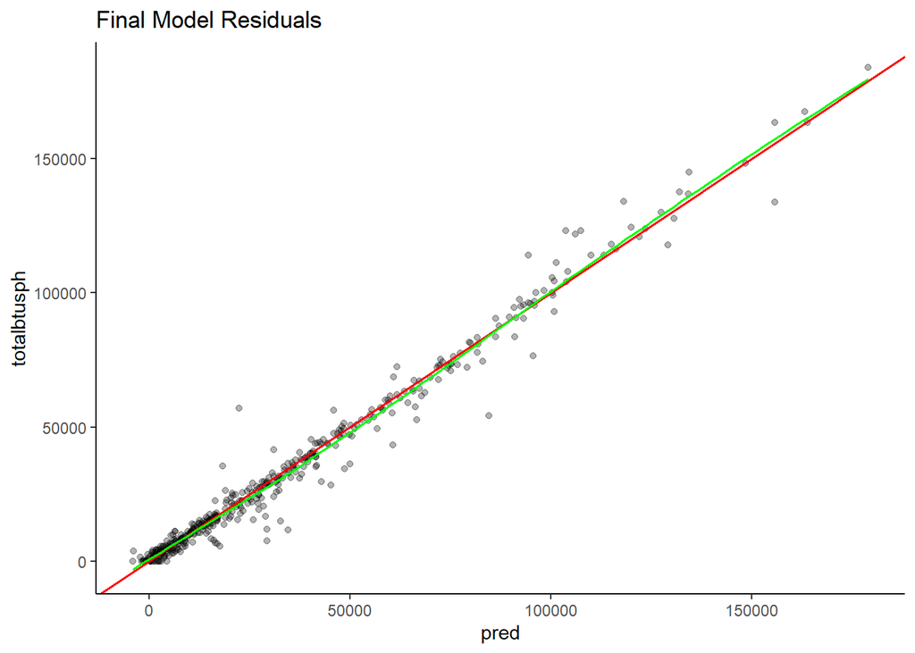

Final Model Fit with all the data

| test_mse | explained |
| --- | --- |
| 27023323 | 0.9788648 |

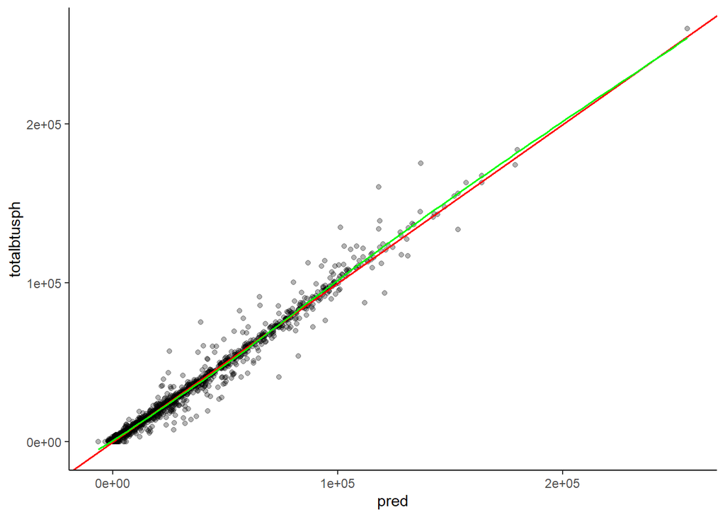

### Final Thoughts

If I were to restart this project knowing what I know now, I would have changed my approach. Instead of selecting variables related to heating, I would have selected variables of easily quantifiable things. Although some of the final predictors are practical, like insulation, or number of children, others are a little less helpful.

Variables Used by Lasso

| variable_name | variable_description | type |
| --- | --- | --- |
| division | Census Division | factor |
| uatyp10 | Census 2010 Urban Type | factor |
| typehuq | Type of housing unit | factor |
| yearmaderange | Range when housing unit was built | factor |
| occupyyrange | Range when household moved in | factor |
| bedrooms | Number of bedrooms | factor |
| ncombath | Number of full bathrooms | factor |
| walltype | Major outside wall material | factor |
| rooftype | Major roofing material | factor |
| highceil | High ceilings | factor |
| windows | Number of windows | factor |
| adqinsul | Level of insulation | factor |
| drafty | Frequency of draft | factor |
| solar | On-site electricity generation from solar | factor |
| heathome | Space heating used | factor |
| fuelheat | Main space heating fuel | factor |
| equipage | Age of main space heating equipment | factor |
| thermain | Any thermostats | factor |
| protherm | Programmable main thermostat | factor |
| equipmuse | Main heating equipment household behavior | factor |
| fuelaux | Secondary space heating fuel | factor |
| baseheat | Heating used in basement | factor |
| attcheat | Heating used in attic | factor |
| gargheat | Heating used in attached garage | factor |
| agecenac | Age of central air conditioner | factor |
| usecenac | Central air conditioner household behavior | factor |
| numberac | Number of individual air conditioning units used | factor |
| wwacage | Age of most-used individual air conditioning unit | factor |
| usewwac | Most-used individual air conditioning unit household behavior | factor |
| swampcol | Swamp cooler used | factor |
| elpay | Who pays for electricity | factor |
| ngpay | Who pays for natural gas | factor |
| hhsex | Respondent sex | factor |
| employhh | Respondent employment status | factor |
| householder_race | Householder (respondent) race | factor |
| numchild | Number of household members age 17 or younger | factor |
| athome | Number of weekdays someone is at home | factor |
| moneypy | Annual gross household income for the last year | factor |
| scalee | Frequency of receiving disconnect notice | factor |
| uselp | Propane used | factor |
| climate_region_pub | Building America Climate Zone | factor |
| iecc_climate_pub | IECC Climate Code | factor |
| hdd30yr | Heating degree days, 30-year average 1981-2010, base temperature 65F | numeric |
| hdd50 | Heating degree days in 2015, base temperature 50F (used for garage heating load estimation only) | numeric |
| cufeetngsph | Natural gas usage for space heating, main and secondary, in hundred cubic feet, 2015 | numeric |
| btungsph | Natural gas usage for space heating, main and secondary, in thousand Btu, 2015 | numeric |
| dollarng | Total natural gas cost, in dollars, 2015 | numeric |
| dolngsph | Natural Gas cost for space heating, main and secondary, in dollars, 2015 | numeric |

It also would have been interesting to explore the variables more closely. Because I had so many, I didn’t get very close to many so it would have been interesting to see the relationships between variables on a localized level.

I also would explore non-linear models. My model fitting was set up to be linear from the moment I decided to use correlation. It does a very good job of explaining the data but I would be interested to see if there were other models that fit as well.